# CREDIT-CARD-ANALYSIS-OF-PSPD-BANK

# Table of Contents

### About the analytics in credit card industry:

Analytics has influenced every industry based on a variety of technology platforms which collect information so, what certainly customers want is known by the service providers. The Credit Card industry is also one of these industries. There is a massive data available that can be useful in infinite ways which is enabled by credit card payment processing,

### Recognition of the customer behavior:

The data from a credit card processor shows the consumer types and their business spending behaviors. Therefore, companies can develop the marketing campaigns that directly addresses consumers’ behavior. In return, this helps to make better sales and the revenue undoubtedly grows. greater sales.

### Problem Statement:

In order to effectively produce quality decisions in the modern credit card industry, knowledge must be gained through effective data analysis and modeling. Through the use of dynamic data driven decision-making tools and procedures, information can be gathered to successfully evaluate all aspects of credit card operations. PSPD Bank has banking operations in more than 50 countries across the globe. Mr. Jim Watson, CEO, wants to evaluate areas of bankruptcy, fraud, and collections, respond to customer requests for help with proactive offers and service.

In this project, I will focus on the effect of the credit card limit on the credit card payments as well as customer spending. Predicting the patterns of spending and payment behaviors of customers is important for banks to provide more appealing offers to the customers, and to respond to customer requests more effectively. Although there are many factors that might be accounted for predicting customers’ spending and payment behaviors, in this project, I will focus on the effect of credit card spending limit. Understanding the role of credit card spending limit will give a valuable input to PSPD bank to see how different amounts of limit affect how much customer spends and how much they pay their credit card debts. Furthermore, illustrating the relationship between credit card spending limit and the payment and spending behaviors of customers will provide evidences for banks to consider in determining the credit card limits for customers from different backgrounds and different spending and payment behaviors.

In analyzing this relationship, I will first look at bilateral correlation between credit card spending limit and credit card payment as well as between the spending limit and the amount of spending with the credit card. After doing the correlational analyses, I will develop machine-learning models. Machine-learning models will help PSD bank to correctly predict how credit card spending limit affects the customer spending and payment behaviors. The analyses will reveal important recommendations that PSPD bank and its CEO might want to consider.

### About the Dataset:

The data for the analyses were acquired from Kaggle.com - Credit Card Exploratory Data Analysis. The data contain three separate files which are ;

- Customer Acquisition: At the time of card issuing, company maintains the details of customers. It has 100 observations and 8 variables including No, Customer, Age,City , Product, Li mit, Company, Segment.
- Spend (Transaction data): Credit card spending for each customer. It has 1500 observations and 5 variables including Sl No, Customer, Month, Type, Amount.
- Repayment: Credit card Payment done by customer. It has 1523 observations and 3 variables including Sl No, Customer, Month, Amount.

The dataset used for this project can be acquired using the following [link](https://www.kaggle.com/darpan25bajaj/credit-card-exploratory-data-analysis#Repayment.csv): [Data Resources](https://www.kaggle.com/darpan25bajaj/credit-card-exploratory-data-analysis)

# 2. Exploratory Data Analysis (EDA)

This section focuses on exploratory data analysis (EDA) which allows us to understand emerging themes before moving onto deeper and more complex data analysis.

```python
customer.head(3)
```

|  | Customer | Age | City | Product | Limit | Company | Segment |
| --- | --- | --- | --- | --- | --- | --- | --- |
| 0 | A1 | 76 | BANGALORE | Gold | 500000.0 | C1 | Self Employed |
| 1 | A2 | 71 | CALCUTTA | Silver | 100000.0 | C2 | Salaried_MNC |
| 2 | A3 | 34 | COCHIN | Platimum | 10000.0 | C3 | Salaried_Pvt |

```python
repayment.head(3)
```

|  | Customer | Month | Amount |
| --- | --- | --- | --- |
| 0 | A1 | 2004-01-12 | 495414.75 |
| 1 | A1 | 2004-01-03 | 245899.02 |
| 2 | A1 | 2004-01-15 | 259490.06 |

```python
spend.head(3)
```

|  | Customer | Month | Type | Amount |
| --- | --- | --- | --- | --- |
| 0 | A1 | 2004-01-12 | JEWELLERY | 485470.80 |
| 1 | A1 | 2004-01-03 | PETRO | 410556.13 |
| 2 | A1 | 2004-01-15 | CLOTHES | 23740.46 |

```python
print(customer.shape)
print(repayment.shape)
print(spend.shape)
```

```
(100, 7)
(1500, 3)
(1500, 4)
```

## 2.1 From the dataset make an inference

### Estimate Customer Age Mean

In case age is less than 18, replace it with mean of age values and estimate customer age mean.

```python
customer.loc[(customer.Age<18),'Age']
```

```
13    16
40    13
62    15
67    12
69    16
89    16
Name: Age, dtype: int64
```

```python
#All the customers who have age less than 18 have been replaced
#by mean of the age column.
customer.loc[(customer.Age<18),'Age']=customer.Age.mean()
```

```python
print('Customers age mean: {}'.format(round(customer.Age.mean(),2)))
```

```
Customers age mean: 48.4
```

### Estimate Spend Amount mean

In case spend amount is more than the limit, replace it with the customer’s limit. (customer’s limit provided in acquisition table is the per transaction limit on his/her card) and estimate spend amount mean.

```python
customer.head(1)
```

|  | Customer | Age | City | Product | Limit | Company | Segment |
| --- | --- | --- | --- | --- | --- | --- | --- |
| 0 | A1 | 76.0 | BANGALORE | Gold | 500000.0 | C1 | Self Employed |

```python
spend.head(1)
```

|  | Customer | Month | Type | Amount |
| --- | --- | --- | --- | --- |
| 0 | A1 | 2004-01-12 | JEWELLERY | 485470.8 |

```python
#merging customer and spend table on the basis of "Customer" column
customer_spend=pd.merge(customer,spend,on=['Customer'],how='inner',suffixes=('_customer','_spend'))
customer_spend.head(3)
```

|  | Customer | Age | City | Product | Limit | Company | Segment | Month | Type | Amount |
| --- | --- | --- | --- | --- | --- | --- | --- | --- | --- | --- |
| 0 | A1 | 76.0 | BANGALORE | Gold | 500000.0 | C1 | Self Employed | 2004-01-12 | JEWELLERY | 485470.80 |
| 1 | A1 | 76.0 | BANGALORE | Gold | 500000.0 | C1 | Self Employed | 2004-01-03 | PETRO | 410556.13 |
| 2 | A1 | 76.0 | BANGALORE | Gold | 500000.0 | C1 | Self Employed | 2004-01-15 | CLOTHES | 23740.46 |

```python
#the customers whose spend amount is more than the limit.
customer_spend.loc[customer_spend.Amount>customer_spend.Limit].head()
```

|  | Customer | Age | City | Product | Limit | Company | Segment | Month | Type | Amount |
| --- | --- | --- | --- | --- | --- | --- | --- | --- | --- | --- |
| 18 | A2 | 71.0 | CALCUTTA | Silver | 100000.0 | C2 | Salaried_MNC | 2004-01-03 | RENTAL | 199554.72 |
| 19 | A2 | 71.0 | CALCUTTA | Silver | 100000.0 | C2 | Salaried_MNC | 2005-02-28 | TRAIN TICKET | 376887.49 |
| 20 | A2 | 71.0 | CALCUTTA | Silver | 100000.0 | C2 | Salaried_MNC | 2004-04-06 | BUS TICKET | 439648.53 |
| 21 | A2 | 71.0 | CALCUTTA | Silver | 100000.0 | C2 | Salaried_MNC | 2004-11-23 | PETRO | 384078.73 |
| 22 | A2 | 71.0 | CALCUTTA | Silver | 100000.0 | C2 | Salaried_MNC | 2005-09-03 | JEWELLERY | 117089.16 |

```python
#if customer's spend amount is more than the limit,replacing with the customer’s limit
customer_spend.loc[(customer_spend.Amount>customer_spend.Limit),'Amount']=customer_spend.Limit
```

```python
print('Spend amount mean : {}'.format(round(customer_spend.Amount.mean(),2)))
```

```
Spend amount mean : 159944.32
```

### Estimate Repayment Amount Mean

Incase the repayment amount is more than the limit, replace the repayment with the limit and estimate repayment amount mean.

```python
customer.head(1)
```

|  | Customer | Age | City | Product | Limit | Company | Segment |
| --- | --- | --- | --- | --- | --- | --- | --- |
| 0 | A1 | 76.0 | BANGALORE | Gold | 500000.0 | C1 | Self Employed |

```python
repayment.head(1)
```

|  | Customer | Month | Amount |
| --- | --- | --- | --- |
| 0 | A1 | 2004-01-12 | 495414.75 |

```python
#merging customer and spend table on the basis of "Customer" column
customer_repayment=pd.merge(customer,repayment,on=['Customer'],how='inner',suffixes=('_customer','_spend'))
customer_repayment.head(3)
```

|  | Customer | Age | City | Product | Limit | Company | Segment | Month | Amount |
| --- | --- | --- | --- | --- | --- | --- | --- | --- | --- |
| 0 | A1 | 76.0 | BANGALORE | Gold | 500000.0 | C1 | Self Employed | 2004-01-12 | 495414.75 |
| 1 | A1 | 76.0 | BANGALORE | Gold | 500000.0 | C1 | Self Employed | 2004-01-03 | 245899.02 |
| 2 | A1 | 76.0 | BANGALORE | Gold | 500000.0 | C1 | Self Employed | 2004-01-15 | 259490.06 |

```python
#the customers where repayment amount is more than the limit.
customer_spend.loc[customer_spend.Amount>customer_spend.Limit].head()
```

|  | Customer | Age | City | Product | Limit | Company | Segment | Month | Type | Amount |
| --- | --- | --- | --- | --- | --- | --- | --- | --- | --- | --- |

```python
#customers where repayment amount is more than the limit, replacing the repayment with the limit.
customer_repayment.loc[(customer_repayment.Amount>customer_repayment.Limit),'Amount']=customer_repayment.Limit
```

```python
print('Repayment amount mean : {}'.format(round(customer_repayment.Amount.mean(),2)))
```

```
Repayment amount mean : 163321.57
```

## 2.2 From the dataset create the following summaries:

### How many distinct customers exist?

```python
distinct_c=customer.Customer.nunique()
print('Number of distinct customer are',distinct_c,'.')
```

```
Number of distinct customer are 100 .
```

### How many distinct categories exist?

#### Customers from Different Spend Type

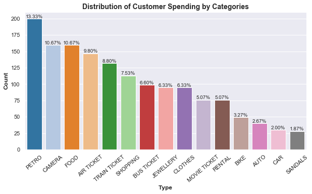

```
Customer Spend Type Value Counts

PETRO           200
CAMERA          160
FOOD            160
AIR TICKET      147
TRAIN TICKET    132
SHOPPING        113
BUS TICKET       99
JEWELLERY        95
CLOTHES          95
MOVIE TICKET     76
RENTAL           76
BIKE             49
AUTO             40
CAR              30
SANDALS          28
Name: Type, dtype: int64
```

```python
# plot the categories of Type column
_ = plt.figure(figsize=(10,5))
ax = sns.countplot(x='Type', data=spend, order=spend['Type'].value_counts().index,palette='tab20')
_ = plt.title('Distribution of Customer Spending by Categories', fontsize=14, fontweight='bold')
_ = plt.ylabel('Count', fontweight='bold')
_ = plt.xlabel('Type', fontweight='bold')
_ = plt.xticks(rotation=40)

# calculate the percentages of the category
sizes=[]
total_data = len(spend)
for p in ax.patches:
    height = p.get_height()
    ax.text(p.get_x()+p.get_width()/2.,height+1,
            '{:1.2f}%'.format(height/total_data*100), ha="center", fontsize=10)

# display the plot
plt.show()

#customer spend type
print('Customer Spend Type Value Counts')
print('')

print(spend.Type.value_counts())
```

#### Customers From Different Cities

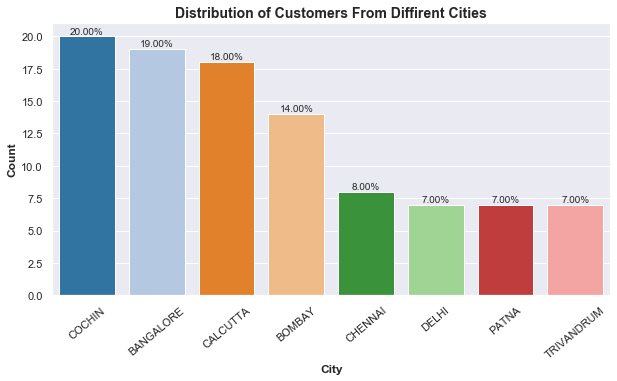

```
Customer City Value Counts

COCHIN        20
BANGALORE     19
CALCUTTA      18
BOMBAY        14
CHENNAI        8
DELHI          7
PATNA          7
TRIVANDRUM     7
Name: City, dtype: int64
```

```python
# plot the categories of City column
_ = plt.figure(figsize=(10,5))
ax = sns.countplot(x='City', data=customer, order=customer['City'].value_counts().index,palette='tab20')
_ = plt.title('Distribution of Customers From Diffirent Cities', fontsize=14, fontweight='bold')
_ = plt.ylabel('Count', fontweight='bold')
_ = plt.xlabel('City', fontweight='bold')
_ = plt.xticks(rotation=40)

# calculate the percentages of the category
sizes=[]
total_data = len(customer)
for p in ax.patches:
    height = p.get_height()
    ax.text(p.get_x()+p.get_width()/2.,height+0.2,
            '{:1.2f}%'.format(height/total_data*100), ha="center", fontsize=10)

# display the plot
plt.show()

#customer spend type
print('Customer City Value Counts')
print('')
print(customer.City.value_counts())
```

#### Customers From Different Products

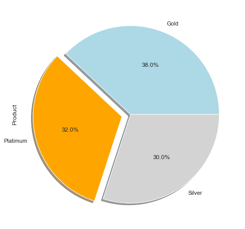

```
Count Products Column

Gold        38
Platimum    32
Silver      30
Name: Product, dtype: int64
```

```python
count_products=customer.Product.value_counts()

plt.figure(figsize=(8,8))
explode = (0, 0.1,0)
colors=['lightblue','orange','lightgrey']

count_products.plot.pie(autopct='%1.1f%%', shadow=True,
                                 explode = explode,colors=colors)
plt.show()
print('Count Products Column')
print('')
print(count_products)
```

**This pie chart shows that there is not a very significant difference on the usage of different credit card products in percentage. It reports that the number of customers using Gold credit cards is higher than those using Silver and Platinum products.**

#### Customers From Different Segments

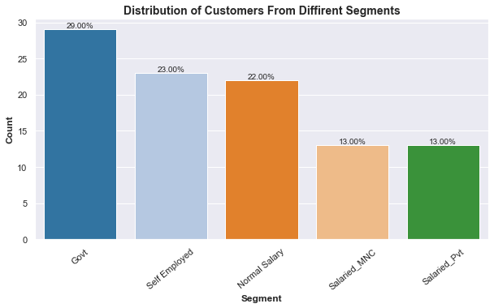

```
Customer Segment Value Counts

Govt             29
Self Employed    23
Normal Salary    22
Salaried_MNC     13
Salaried_Pvt     13
Name: Segment, dtype: int64
```

```python
# plot the categories of Segment column
_ = plt.figure(figsize=(10,5))
ax = sns.countplot(x='Segment', data=customer, order=customer['Segment'].value_counts().index,palette='tab20')
_ = plt.title('Distribution of Customers From Diffirent Segments', fontsize=14, fontweight='bold')
_ = plt.ylabel('Count', fontweight='bold')
_ = plt.xlabel('Segment', fontweight='bold')
_ = plt.xticks(rotation=40)

# calculate the percentages of the category
sizes=[]
total_data = len(customer)
for p in ax.patches:
    height = p.get_height()
    ax.text(p.get_x()+p.get_width()/2.,height+0.2,
            '{:1.2f}%'.format(height/total_data*100), ha="center", fontsize=10)

# display the plot
plt.show()

#customer Segment
print('Customer Segment Value Counts')
print('')
print(customer.Segment.value_counts())
```

**This bar graph illustrates economic status of the customers in the sample. It shows that the number of customers working for government (29%) is higher than people from other occupation groups.**

### What is the average monthly spend by customers?

```python
#creating new columns which show "Month" and "Year"
customer_spend['Yearly']=customer_spend.Month.dt.strftime('%Y')
customer_spend['Monthly']=customer_spend.Month.apply(lambda x:pd.Timestamp.strftime(x,format="%B"))
customer_spend.head(3)
```

|  | Customer | Age | City | Product | Limit | Company | Segment | Month | Type | Amount | Yearly | Monthly |
| --- | --- | --- | --- | --- | --- | --- | --- | --- | --- | --- | --- | --- |
| 0 | A1 | 76.0 | BANGALORE | Gold | 500000.0 | C1 | Self Employed | 2004-01-12 | JEWELLERY | 485470.80 | 2004 | January |
| 1 | A1 | 76.0 | BANGALORE | Gold | 500000.0 | C1 | Self Employed | 2004-01-03 | PETRO | 410556.13 | 2004 | January |
| 2 | A1 | 76.0 | BANGALORE | Gold | 500000.0 | C1 | Self Employed | 2004-01-15 | CLOTHES | 23740.46 | 2004 | January |

```
                     Amount
Yearly Monthly
2004   April      139622.26
       February   158605.87
       January    159641.37
       March      148708.23
       May        164398.63
       November   112142.61
       September  183365.30
2005   April      158038.28
       August     153314.83
       December    95844.82
       February   164453.66
       January    197271.89
       July       132946.23
       June       202155.17
       May        167804.64
       November   191929.94
       October    105236.96
       September  127995.60
2006   April      149956.71
       August     214221.06
       December   165129.65
       February   158122.12
       January    151669.87
       July       207124.75
       June       163114.50
       March      146444.09
       May        159586.84
       November   150355.50
       October    173227.86
       September  146320.68
```

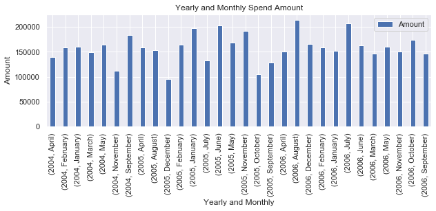

```python
#grouping the dataset based on 'Yearly' and 'monthly'
spend_group=round(customer_spend.groupby(['Yearly','Monthly'])[['Amount']].mean(),2)

spend_group.plot(kind='bar',figsize=(10,3),width=(0.4))
plt.xlabel('Yearly and Monthly')
plt.ylabel('Amount')
plt.title('Yearly and Monthly Spend Amount')
#plt.margins(0.02)

print(spend_group)
```

The graph below shows the same two-year distribution for repayment by customers. It demonstrates that the highest amount of repayments is reported on October 2006 and January 2006. The least amount of repayment by customers is reported on September 2005.

```
   Thus, the dates of the highest and lowest customer spending do not match with the dates of the highest and lowest repayment by customers.
```

### What is the average monthly repayment by customers?

```python
customer_repayment.head(3)
```

|  | Customer | Age | City | Product | Limit | Company | Segment | Month | Amount |
| --- | --- | --- | --- | --- | --- | --- | --- | --- | --- |
| 0 | A1 | 76.0 | BANGALORE | Gold | 500000.0 | C1 | Self Employed | 2004-01-12 | 495414.75 |
| 1 | A1 | 76.0 | BANGALORE | Gold | 500000.0 | C1 | Self Employed | 2004-01-03 | 245899.02 |
| 2 | A1 | 76.0 | BANGALORE | Gold | 500000.0 | C1 | Self Employed | 2004-01-15 | 259490.06 |

```python
#creating new columns which show "Month" and "Year"
customer_repayment['Yearly']=customer_repayment.Month.dt.year
customer_repayment['Monthly']=customer_repayment.Month.apply(lambda x:pd.Timestamp.strftime(x,format="%B"))
customer_repayment.head(2)
```

|  | Customer | Age | City | Product | Limit | Company | Segment | Month | Amount | Yearly | Monthly |
| --- | --- | --- | --- | --- | --- | --- | --- | --- | --- | --- | --- |
| 0 | A1 | 76.0 | BANGALORE | Gold | 500000.0 | C1 | Self Employed | 2004-01-12 | 495414.75 | 2004 | January |
| 1 | A1 | 76.0 | BANGALORE | Gold | 500000.0 | C1 | Self Employed | 2004-01-03 | 245899.02 | 2004 | January |

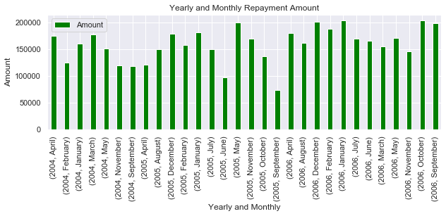

```python
#grouping the dataset based on 'Yearly' and 'monthly'
groupby_ym=round(customer_repayment.groupby(['Yearly','Monthly'])[['Amount']].mean(),2).sort_values(by=['Yearly','Monthly'])
#print(groupby_ym.head(2))

groupby_ym.plot(kind='bar',figsize=(10,3),width=(0.4),color='green')
plt.xlabel('Yearly and Monthly')
plt.ylabel('Amount')
plt.title('Yearly and Monthly Repayment Amount')
#plt.margins(0.02)
```

The above graph demonstrates yearly and monthly distribution of credit card payments. It demonstrates that the highest amounts of credit card payments have been made in October 2006 and January 2006. The lowest amount of payment is reported on September 2005.

```
The evidence in this graph and the previous graph suggest that we don’t see an overlap in terms of the dates of highest credit card payments and highest customer spending.
```

### What are the top 5 product types?

```python
spend.head(2)
```

|  | Customer | Month | Type | Amount |
| --- | --- | --- | --- | --- |
| 0 | A1 | 2004-01-12 | JEWELLERY | 485470.80 |
| 1 | A1 | 2004-01-03 | PETRO | 410556.13 |

```python
spend.Type.value_counts().sort_values(ascending=False).head()
```

```
PETRO           200
FOOD            160
CAMERA          160
AIR TICKET      147
TRAIN TICKET    132
Name: Type, dtype: int64
```

### Which city is having maximum spend?

```python
city_spend=customer_spend.groupby("City")["Amount"].sum().sort_values(ascending=False)
city_spend
```

```
City
COCHIN        49378593.00
BANGALORE     44746735.52
CALCUTTA      43333193.30
BOMBAY        32298185.88
CHENNAI       22883652.65
PATNA         17410601.97
TRIVANDRUM    16397180.37
DELHI         13468330.04
Name: Amount, dtype: float64
```

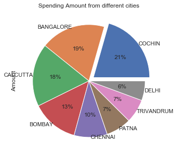

```python
plt.figure(figsize=(5,12))
city_spend.plot(kind="pie",autopct="%1.0f%%",shadow=False,labeldistance=1,explode=[0.1,0.0,0.0,0.0,0.0,0.0,0.0,0.0])
plt.title("Spending Amount from different cities")
plt.show()
```

Cities Spending Ratio :  
In the pie chart above, we have illustrated the amount of customer spending in different cities. It reports the highest customer spending is produced in Cochin, which is not surprising because it includes the largest amounts of customers in the sample.

### Which age group is spending more money?

```python
#creating new column "Age Group" with 8 bins between 18 to 90
customer_spend["Age Group"] =  pd.cut(customer_spend["Age"],bins=np.arange(18,90,12),labels=["18-30","30-42",'42-54' ,"54-66" ,"66-82"],include_lowest=True)
customer_spend.head(2)
```

|  | Customer | Age | City | Product | Limit | Company | Segment | Month | Type | Amount | Yearly | Monthly | Age Group |
| --- | --- | --- | --- | --- | --- | --- | --- | --- | --- | --- | --- | --- | --- |
| 0 | A1 | 76.0 | BANGALORE | Gold | 500000.0 | C1 | Self Employed | 2004-01-12 | JEWELLERY | 485470.80 | 2004 | January | 66-82 |
| 1 | A1 | 76.0 | BANGALORE | Gold | 500000.0 | C1 | Self Employed | 2004-01-03 | PETRO | 410556.13 | 2004 | January | 66-82 |

```python
#grouping data based on "Age Group" and finding the amount spend by each age group and arranging in descending oreder
age_spend = customer_spend.groupby("Age Group")['Amount'].sum().sort_values(ascending=False)
age_spend
```

```
Age Group
42-54    78751818.53
18-30    56064951.71
30-42    45730394.75
66-82    39922277.07
54-66    17992493.48
Name: Amount, dtype: float64
```

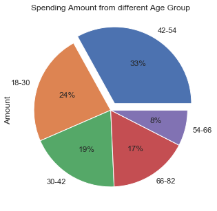

```
'From the pie chart shown above we can say that age group 42 - 54 is spending more money'
```

```python
plt.figure(figsize=(5,10))
age_spend.plot(kind = "pie",autopct="%1.0f%%",explode=[0.1,0.0,0.0,0.0,0.0],shadow=False)
plt.title("Spending Amount from different Age Group")
plt.show()
'''From the pie chart shown above we can say that age group 42 - 54 is spending more money'''
```

## 2.3 Distribution of the City Wise Spending on each Product by Year

Calculate the city wise spend on each product on yearly basis. Also include a graphical representation for the same.

```python
customer_spend.head(2)
```

|  | Customer | Age | City | Product | Limit | Company | Segment | Month | Type | Amount | Yearly | Monthly | Age Group |
| --- | --- | --- | --- | --- | --- | --- | --- | --- | --- | --- | --- | --- | --- |
| 0 | A1 | 76.0 | BANGALORE | Gold | 500000.0 | C1 | Self Employed | 2004-01-12 | JEWELLERY | 485470.80 | 2004 | January | 66-82 |
| 1 | A1 | 76.0 | BANGALORE | Gold | 500000.0 | C1 | Self Employed | 2004-01-03 | PETRO | 410556.13 | 2004 | January | 66-82 |

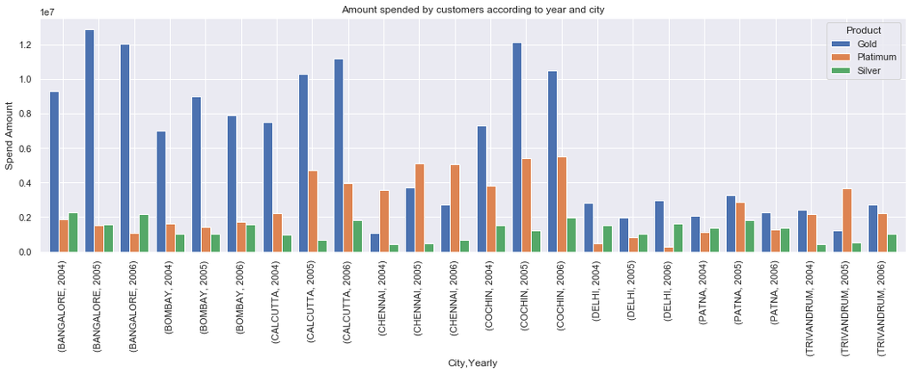

```python
customer_spend_cy = pd.pivot_table(data = customer_spend,index=["City","Yearly"],columns='Product',aggfunc="sum",values="Amount")
#print(round(customer_spend_p,1))

customer_spend_cy.plot(kind="bar",figsize=(18,5),width=0.8)
plt.ylabel("Spend Amount")
plt.title("Amount spended by customers according to year and city")
plt.show()
```

## 2.4 Distribution of the Segment Wise Spend

Calculate the segment wise spend on each product and calculate the segment wise spend. Also include a graphical representation for the same.

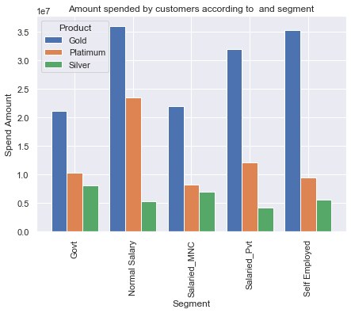

```
Product              Gold    Platimum     Silver
Segment
Govt           21100064.8  10263746.6  8118430.3
Normal Salary  35904701.9  23506868.9  5270799.2
Salaried_MNC   21914735.3   8200598.2  6904079.6
Salaried_Pvt   31974024.2  12168587.6  4208467.9
Self Employed  35306828.8   9482842.6  5591696.8
```

```python
customer_spend_ss = pd.pivot_table(data = customer_spend,index="Segment",columns='Product',aggfunc="sum",values="Amount")


customer_spend_ss.plot(kind="bar",figsize=(7,5),width=0.8)
plt.ylabel("Spend Amount")
plt.title("Amount spended by customers according to  and segment")
plt.show()
print(round(customer_spend_ss,1))
```

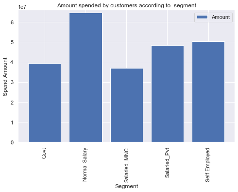

```
                   Amount
Segment
Govt           39482241.7
Normal Salary  64682370.0
Salaried_MNC   37019413.1
Salaried_Pvt   48351079.8
Self Employed  50381368.2
```

```python
#calculate the segment wise spend. Also include a graphical representation for the same
customer_spend_ss = pd.pivot_table(data = customer_spend,index=["Segment"],aggfunc="sum",values="Amount")

customer_spend_ss.plot(kind="bar",figsize=(8,5),width=0.8)
plt.margins(0.02)
plt.ylabel("Spend Amount")
plt.title("Amount spended by customers according to  segment")
plt.show()
print(round(customer_spend_ss,1))
```

**The two graphs above show the distribution of customer spending based on different economic segments. Both graphs suggest that people with normal salary are making the highest spending compared to customers in the other economic segments, particularly those having gold and platinum credit cards. However, the amount of spending made by the customers at the normal salary segment who use silver credit cards is not at the highest level, compared to customers at other economic segments who use silver cards. The graph on the left suggests that customers who work in government jobs and use silver cards make higher amounts of spending than those with silver cards at other economic segments.**

## 2.5 Distribution of the Segment Wise Repayment

Calculate the segment wise repayment on each product and calculate the segment wise repayment. Also include a graphical representation for the same.

```python
customer_repayment.head(2)
```

|  | Customer | Age | City | Product | Limit | Company | Segment | Month | Amount | Yearly | Monthly |
| --- | --- | --- | --- | --- | --- | --- | --- | --- | --- | --- | --- |
| 0 | A1 | 76.0 | BANGALORE | Gold | 500000.0 | C1 | Self Employed | 2004-01-12 | 495414.75 | 2004 | January |
| 1 | A1 | 76.0 | BANGALORE | Gold | 500000.0 | C1 | Self Employed | 2004-01-03 | 245899.02 | 2004 | January |

```
Product              Gold    Platimum     Silver
Segment
Govt           25324822.4   8481453.4  7719992.6
Normal Salary  36613898.2  23237460.8  5045391.2
Salaried_MNC   25178098.8   8064845.3  6978795.5
Salaried_Pvt   33485355.3   9994977.9  4124790.4
Self Employed  37433866.3   7850995.4  5447616.4
```

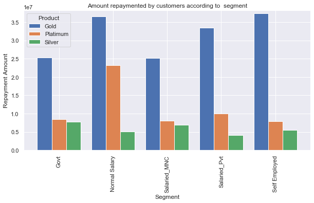

```python
#Calculate the segment wise repayment on each product.Also include a graphical representation for the same.

customer_repayment_sr=pd.pivot_table(data=customer_repayment,index='Segment',columns='Product',values='Amount',aggfunc='sum')

print(round(customer_repayment_sr,1))
customer_repayment_sr.plot(kind='bar',figsize=(10,5),width=(0.8))
plt.margins(0.02)
plt.ylabel("Repayment Amount")
plt.title("Amount repaymented by customers according to  segment")
plt.show()
```

```
                   Amount
Segment
Govt           41526268.5
Normal Salary  64896750.3
Salaried_MNC   40221739.5
Salaried_Pvt   47605123.7
Self Employed  50732478.1
```

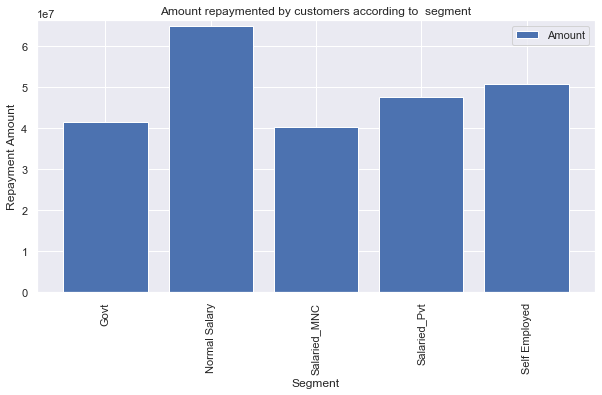

```python
#calculate the segment wise repayment. Also include a graphical representation for the same
customer_repayment_sr=pd.pivot_table(data=customer_repayment,index='Segment',values='Amount',aggfunc='sum')

print(round(customer_repayment_sr,1))
customer_repayment_sr.plot(kind='bar',figsize=(10,5),width=(0.8))
plt.margins(0.02)
plt.ylabel("Repayment Amount")
plt.title("Amount repaymented by customers according to  segment")
plt.show()
```

## 2.6 Create graphs for

### Seasonal comparison of total spends, city wise

```python
customer_spend.head(2)
```

|  | Customer | Age | City | Product | Limit | Company | Segment | Month | Type | Amount | Yearly | Monthly | Age Group |
| --- | --- | --- | --- | --- | --- | --- | --- | --- | --- | --- | --- | --- | --- |
| 0 | A1 | 76.0 | BANGALORE | Gold | 500000.0 | C1 | Self Employed | 2004-01-12 | JEWELLERY | 485470.80 | 2004 | January | 66-82 |
| 1 | A1 | 76.0 | BANGALORE | Gold | 500000.0 | C1 | Self Employed | 2004-01-03 | PETRO | 410556.13 | 2004 | January | 66-82 |

```python
seasonal=[]
for i in customer_spend.Monthly :
    if i in ['December','January','February'] :
        seasonal.append('Winter')
    elif i in ['March','April','May'] :
        seasonal.append('Spring')
    elif i in ['June','July','August']:
        seasonal.append('Summer')
    else :
        seasonal.append('Fall')
customer_spend['Seasonal']=seasonal
customer_spend.head(2)
```

|  | Customer | Age | City | Product | Limit | Company | Segment | Month | Type | Amount | Yearly | Monthly | Age Group | Seasonal |
| --- | --- | --- | --- | --- | --- | --- | --- | --- | --- | --- | --- | --- | --- | --- |
| 0 | A1 | 76.0 | BANGALORE | Gold | 500000.0 | C1 | Self Employed | 2004-01-12 | JEWELLERY | 485470.80 | 2004 | January | 66-82 | Winter |
| 1 | A1 | 76.0 | BANGALORE | Gold | 500000.0 | C1 | Self Employed | 2004-01-03 | PETRO | 410556.13 | 2004 | January | 66-82 | Winter |

```python
#grouping data based on "Seasonal" and "City" columns
month_city = customer_spend.groupby(["Seasonal","City"])[["Amount"]].sum().sort_index().reset_index()
month_city.head(2)
```

|  | Seasonal | City | Amount |
| --- | --- | --- | --- |
| 0 | Fall | BANGALORE | 4425229.46 |
| 1 | Fall | BOMBAY | 5396466.89 |

```python
#creating pivot table based on "Seasonal" and "City" columns
seasonal_city =pd.pivot_table(data=customer_spend,values='Amount',index='City',columns='Seasonal',aggfunc='sum')
seasonal_city
```

| Seasonal City | Fall | Spring | Summer | Winter |
| --- | --- | --- | --- | --- |
| BANGALORE | 4425229.46 | 17584032.68 | 4663972.54 | 18073500.84 |
| BOMBAY | 5396466.89 | 12403603.61 | 2617067.04 | 11881048.34 |
| CALCUTTA | 4121959.33 | 15029822.36 | 6100977.10 | 18080434.51 |
| CHENNAI | 2304787.35 | 8963509.82 | 2318945.40 | 9296410.08 |
| COCHIN | 5753803.89 | 17514012.16 | 6308953.48 | 19801823.47 |
| DELHI | 656230.92 | 5644725.34 | 966686.25 | 6200687.53 |
| PATNA | 813545.16 | 6861939.94 | 1565570.77 | 8169546.10 |
| TRIVANDRUM | 675034.52 | 7020156.44 | 1184597.77 | 7517391.64 |

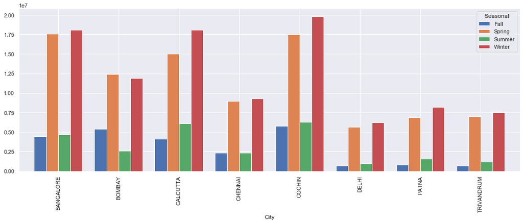

```python
seasonal_city.plot(kind="bar",figsize=(18,6),width=0.8)
plt.show()
```

**The graph above illustrates the seasonal distribution of customer spending on different cities. It reports that the winter season sees highest amount of customer spending, except for the city of Bombay where the customer spending in spring is higher than the seasons. The highest winter season spending has been made in Cochin, the highest spring season spending has been made in Cochin and Bangalore, the highest fall spending has been made in Bombay and Cochin. Finally, the highest summer spending has been made in Cochin and Calcutta.**

### Comparison of seasonal spend for each product (look for any seasonality that exists in terms of spend)

```python
#creating pivot table based on "Monthly" and "Product" columns
product_wise = pd.pivot_table(data=customer_spend,index='Product',columns='Seasonal',values='Amount',aggfunc='sum')
product_wise
```

| Seasonal Product | Fall | Spring | Summer | Winter |
| --- | --- | --- | --- | --- |
| Gold | 16038378.46 | 53975714.83 | 16660309.43 | 59525952.34 |
| Platimum | 5924759.80 | 23443349.53 | 6453648.27 | 27800886.28 |
| Silver | 2183919.26 | 13602737.99 | 2612812.65 | 11694003.89 |

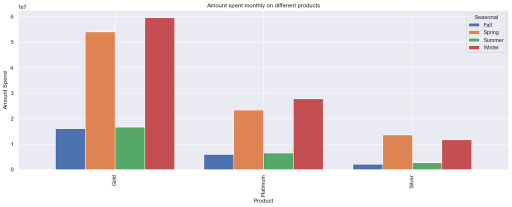

```python
product_wise.plot(kind="bar",figsize=(18,6),width=0.8)
plt.ylabel("Amount Spend")
plt.title("Amount spent monthly on different products")
plt.show()
```

**In the graph above, I have made a comparison across three products based on season. It shows that the highest customer spending with gold and platinum cards have been made in winter season. As for the customer spending with the silver card, the highest spending has been made in spring season.**

We can see from the above graph that the sales are high for all the Products during the seasons:

- Winter
- Spring

Out of these seasons,highest sales are in Winter.

### Comparison histogram of log10 spend amount and repayment amount

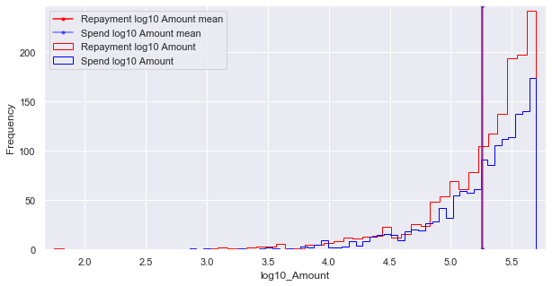

```python
spend['log10_Amount_Spend']=np.log10(spend['Amount'])
repayment['log10_Amount_Repayment']=np.log10(repayment['Amount'])

plt.figure(figsize=(10,5))
plt.margins(0.02)

repayment.log10_Amount_Repayment.plot.hist(histtype='step', bins=50,color='red',label='Repayment log10 Amount')
spend.log10_Amount_Spend.plot.hist(histtype='step',bins=50,color='blue',label='Spend log10 Amount')

plt.xlabel('log10_Amount')
plt.axvline(repayment.log10_Amount_Repayment.mean(),marker='.',color='red',label='Repayment log10 Amount mean')
plt.axvline(spend.log10_Amount_Spend.mean(),marker='.',color='blue',label='Spend log10 Amount mean',alpha=0.5)

plt.legend()
```

## 2.7 Correlation Between Features

Before looking at the correlation structure between the features in our project, we need to convert the features with "Object" data type to "Categorical" data type.

```python
one_table=pd.merge(customer_spend,repayment,how='inner',on=['Customer','Month'],suffixes=('_spend','_repayment'))

one_table.head(2)
```

|  | Customer | Age | City | Product | Limit | Company | Segment | Month | Type | Amount_spend | Yearly | Monthly | Age Group | Seasonal | Amount_repayment | log10_Amount_Repayment |
| --- | --- | --- | --- | --- | --- | --- | --- | --- | --- | --- | --- | --- | --- | --- | --- | --- |
| 0 | A1 | 76.0 | BANGALORE | Gold | 500000.0 | C1 | Self Employed | 2004-01-12 | JEWELLERY | 485470.8 | 2004 | January | 66-82 | Winter | 495414.75 | 5.694969 |
| 1 | A1 | 76.0 | BANGALORE | Gold | 500000.0 | C1 | Self Employed | 2004-01-12 | JEWELLERY | 485470.8 | 2004 | January | 66-82 | Winter | 350446.82 | 5.544622 |

```python
one_table=one_table.drop(['log10_Amount_Repayment'],axis=1)
one_table.head(2)
```

|  | Customer | Age | City | Product | Limit | Company | Segment | Month | Type | Amount_spend | Yearly | Monthly | Age Group | Seasonal | Amount_repayment |
| --- | --- | --- | --- | --- | --- | --- | --- | --- | --- | --- | --- | --- | --- | --- | --- |
| 0 | A1 | 76.0 | BANGALORE | Gold | 500000.0 | C1 | Self Employed | 2004-01-12 | JEWELLERY | 485470.8 | 2004 | January | 66-82 | Winter | 495414.75 |
| 1 | A1 | 76.0 | BANGALORE | Gold | 500000.0 | C1 | Self Employed | 2004-01-12 | JEWELLERY | 485470.8 | 2004 | January | 66-82 | Winter | 350446.82 |

```python
# define a temporary data frame
df_temp = one_table.copy()
```

```python
# select the features with "Object" data type
df_Obj = df_temp.select_dtypes(include='object')

# check the number of columns with "Object" data type
df_Obj.shape
```

```
(863, 9)
```

```python
# define a lambda function to be used to convert object type to
# categorical data type
categorize_label = lambda x: x.astype('category').cat.codes

# convert the columns with "Object" data type to "Categorical" data type
df_temp[df_Obj.columns] = df_temp[df_Obj.columns].apply(categorize_label, axis=0)
```

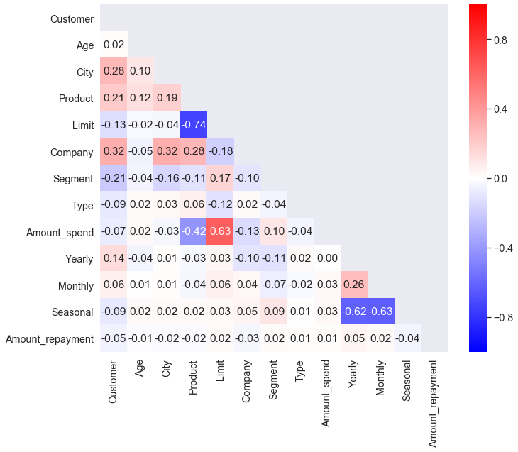

```python
# Now let's visualize the correlations
# Generate a mask for the upper triangle
mask = np.zeros_like(df_temp.corr(), dtype=np.bool)
mask[np.triu_indices_from(mask)] = True


_ = plt.figure(figsize=(11,9))
_ = sns.set(font_scale=1.3)
ax = sns.heatmap(df_temp.corr(), vmin=-1, vmax=1,square=True,
                 annot=True, cmap='bwr', cbar=True, fmt=".2f",mask=mask)


# display the heatmap
plt.show()
```

Since the data includes many features, the entire dataset was divided into two parts to create a correlation matrix by using the heatmap that is illustrated below. Features with object data type were converted into categorical data type and the correlation matrix below includes those features with categorical codes.

The first(above) heatmap illustrates the relationships between the variables. While the red color indicates a positive correlation between the two variables, blue color indicates negative correlation. The magnitudes of correlations have also been shown on the heatmap. In the second heatmap, I looked at only the variables of interest in my project, which are credit card spending limit, customer spending, and credit card payments.

```python
df_temp=df_temp[['Limit','Amount_spend','Amount_repayment','Product']]
#temp_features=df_temp.columns
#x1=list(temp_features[5,10,15])
#temp_features
df_temp
```

|  | Limit | Amount_spend | Amount_repayment | Product |
| --- | --- | --- | --- | --- |
| 0 | 500000.0 | 485470.80 | 495414.75 | 0 |
| 1 | 500000.0 | 485470.80 | 350446.82 | 0 |
| 2 | 500000.0 | 440563.22 | 495414.75 | 0 |
| 3 | 500000.0 | 440563.22 | 350446.82 | 0 |
| 4 | 500000.0 | 410556.13 | 245899.02 | 0 |
| ... | ... | ... | ... | ... |
| 858 | 100000.0 | 54729.66 | 310992.30 | 2 |
| 859 | 10000.0 | 10000.00 | 121874.90 | 1 |
| 860 | 10001.0 | 10001.00 | 337815.57 | 1 |
| 861 | 10002.0 | 10002.00 | 25682.73 | 1 |
| 862 | 100000.0 | 100000.00 | 69551.19 | 2 |

863 rows × 4 columns

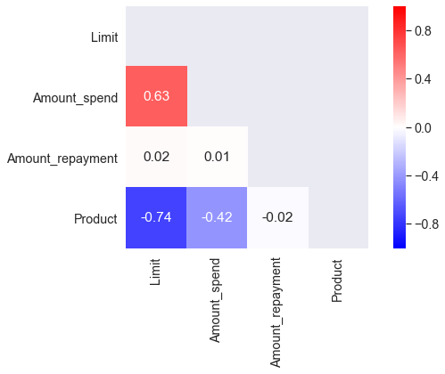

```python
# Now let's visualize the correlations
# Generate a mask for the upper triangle
mask = np.zeros_like(df_temp.corr(), dtype=np.bool)
mask[np.triu_indices_from(mask)] = True

_ = plt.figure(figsize=(10,5))
_ = sns.set(font_scale=1.3)
ax = sns.heatmap(df_temp.corr(), vmin=-1, vmax=1,square=True,
                 annot=True, cmap='bwr', cbar=True, fmt=".2f",mask=mask)


# display the heatmap
plt.show()
```